# Project: Wrangling and Analyze Data

## Data Gathering

In the cell below, gather **all** three pieces of data for this project and load them in the notebook. **Note:** the methods required to gather each data are different.

1. Directly download the WeRateDogs Twitter archive data (twitter_archive_enhanced.csv)

```python
import pandas as pd
```

```python
archive=pd.read_csv('twitter-archive-enhanced.csv')
```

1. Use the Requests library to download the tweet image prediction (image_predictions.tsv)

```python
import requests
url = 'https://d17h27t6h515a5.cloudfront.net/topher/2017/August/599fd2ad_image-predictions/image-predictions.tsv'
response = requests.get(url)
```

```python
predictions = pd.read_csv(url, sep='\t')
```

1. Use the Tweepy library to query additional data via the Twitter API (tweet_json.txt)

```python
# My Twitter Developer account was denied so i downloaded the 'tweet_json.txt' from the classroom
import json
```

```python
df = []
with open('tweet_json.txt') as f:
    for line in f:
        tweet = (json.loads(line))
        tweet_id = tweet['id']
        retweet_count = tweet['retweet_count']
        favorite_count = tweet['favorite_count']
        create_date = tweet['created_at']
        df.append({'retweet_count' : retweet_count,
                  'favorite_count' : favorite_count,
                  'create_date' : create_date,
                  'tweet_id' : tweet_id})

json = pd.DataFrame(df, columns = ['tweet_id', 'retweet_count', 'favorite_count', 'create_date'])
```

## Assessing Data

In this section, detect and document at least **eight (8) quality issues and two (2) tidiness issue**. You must use **both** visual assessment programmatic assessement to assess the data.

**Note:** pay attention to the following key points when you access the data.

## Assessing The Archive Data Table

```python
archive.head()
```

|  | tweet_id | in_reply_to_status_id | in_reply_to_user_id | timestamp | source | text | retweeted_status_id | retweeted_status_user_id | retweeted_status_timestamp | expanded_urls | rating_numerator | rating_denominator | name | doggo | floofer | pupper | puppo |
| --- | --- | --- | --- | --- | --- | --- | --- | --- | --- | --- | --- | --- | --- | --- | --- | --- | --- |
| 0 | 892420643555336193 | NaN | NaN | 2017-08-01 16:23:56 +0000 | <a href="http://twitter.com/download/iphone" r... | This is Phineas. He's a mystical boy. Only eve... | NaN | NaN | NaN | https://twitter.com/dog_rates/status/892420643... | 13 | 10 | Phineas | None | None | None | None |
| 1 | 892177421306343426 | NaN | NaN | 2017-08-01 00:17:27 +0000 | <a href="http://twitter.com/download/iphone" r... | This is Tilly. She's just checking pup on you.... | NaN | NaN | NaN | https://twitter.com/dog_rates/status/892177421... | 13 | 10 | Tilly | None | None | None | None |
| 2 | 891815181378084864 | NaN | NaN | 2017-07-31 00:18:03 +0000 | <a href="http://twitter.com/download/iphone" r... | This is Archie. He is a rare Norwegian Pouncin... | NaN | NaN | NaN | https://twitter.com/dog_rates/status/891815181... | 12 | 10 | Archie | None | None | None | None |
| 3 | 891689557279858688 | NaN | NaN | 2017-07-30 15:58:51 +0000 | <a href="http://twitter.com/download/iphone" r... | This is Darla. She commenced a snooze mid meal... | NaN | NaN | NaN | https://twitter.com/dog_rates/status/891689557... | 13 | 10 | Darla | None | None | None | None |
| 4 | 891327558926688256 | NaN | NaN | 2017-07-29 16:00:24 +0000 | <a href="http://twitter.com/download/iphone" r... | This is Franklin. He would like you to stop ca... | NaN | NaN | NaN | https://twitter.com/dog_rates/status/891327558... | 12 | 10 | Franklin | None | None | None | None |

```python
archive.sample(5)
```

|  | tweet_id | in_reply_to_status_id | in_reply_to_user_id | timestamp | source | text | retweeted_status_id | retweeted_status_user_id | retweeted_status_timestamp | expanded_urls | rating_numerator | rating_denominator | name | doggo | floofer | pupper | puppo |
| --- | --- | --- | --- | --- | --- | --- | --- | --- | --- | --- | --- | --- | --- | --- | --- | --- | --- |
| 2275 | 667453023279554560 | NaN | NaN | 2015-11-19 21:22:56 +0000 | <a href="http://twitter.com" rel="nofollow">Twitter Web Client</a> | Meet Cupcake. I would do unspeakable things for Cupcake. 11/10 https://t.co/6uLCWR9Efa | NaN | NaN | NaN | https://twitter.com/dog_rates/status/667453023279554560/photo/1 | 11 | 10 | Cupcake | None | None | None | None |
| 776 | 776113305656188928 | NaN | NaN | 2016-09-14 17:40:06 +0000 | <a href="http://twitter.com/download/iphone" rel="nofollow">Twitter for iPhone</a> | This is Sampson. He's about to get hit with a vicious draw 2. Has no idea. 11/10 poor pupper https://t.co/FYT9QBEnKG | NaN | NaN | NaN | https://twitter.com/dog_rates/status/776113305656188928/photo/1 | 11 | 10 | Sampson | None | None | pupper | None |
| 1392 | 700062718104104960 | NaN | NaN | 2016-02-17 21:02:13 +0000 | <a href="http://twitter.com/download/iphone" rel="nofollow">Twitter for iPhone</a> | This is Eazy-E. He's colorful af. Must be rare. Submerged in Sprite (rad). Doesn't perform well when not wet. 6/10 https://t.co/UtFI7eUCjE | NaN | NaN | NaN | https://twitter.com/dog_rates/status/700062718104104960/photo/1 | 6 | 10 | Eazy | None | None | None | None |
| 947 | 752519690950500352 | NaN | NaN | 2016-07-11 15:07:30 +0000 | <a href="http://twitter.com/download/iphone" rel="nofollow">Twitter for iPhone</a> | Hopefully this puppo on a swing will help get you through your Monday. 11/10 would push https://t.co/G54yClasz2 | NaN | NaN | NaN | https://twitter.com/dog_rates/status/752519690950500352/photo/1,https://twitter.com/dog_rates/status/752519690950500352/photo/1,https://twitter.com/dog_rates/status/752519690950500352/photo/1 | 11 | 10 | None | None | None | None | puppo |
| 1808 | 676897532954456065 | NaN | NaN | 2015-12-15 22:52:02 +0000 | <a href="http://twitter.com/download/iphone" rel="nofollow">Twitter for iPhone</a> | Exotic handheld dog here. Appears unathletic. Feet look deadly. Can be thrown a great distance. 5/10 might pet idk https://t.co/Avq4awulqk | NaN | NaN | NaN | https://twitter.com/dog_rates/status/676897532954456065/photo/1 | 5 | 10 | None | None | None | None | None |

```python
archive.info()
```

```
<class 'pandas.core.frame.DataFrame'>
RangeIndex: 2356 entries, 0 to 2355
Data columns (total 17 columns):
 #   Column                      Non-Null Count  Dtype
---  ------                      --------------  -----
 0   tweet_id                    2356 non-null   int64
 1   in_reply_to_status_id       78 non-null     float64
 2   in_reply_to_user_id         78 non-null     float64
 3   timestamp                   2356 non-null   object
 4   source                      2356 non-null   object
 5   text                        2356 non-null   object
 6   retweeted_status_id         181 non-null    float64
 7   retweeted_status_user_id    181 non-null    float64
 8   retweeted_status_timestamp  181 non-null    object
 9   expanded_urls               2297 non-null   object
 10  rating_numerator            2356 non-null   int64
 11  rating_denominator          2356 non-null   int64
 12  name                        2356 non-null   object
 13  doggo                       2356 non-null   object
 14  floofer                     2356 non-null   object
 15  pupper                      2356 non-null   object
 16  puppo                       2356 non-null   object
dtypes: float64(4), int64(3), object(10)
memory usage: 313.0+ KB
```

```python
archive.describe()
```

|  | tweet_id | in_reply_to_status_id | in_reply_to_user_id | retweeted_status_id | retweeted_status_user_id | rating_numerator | rating_denominator |
| --- | --- | --- | --- | --- | --- | --- | --- |
| count | 2.356000e+03 | 7.800000e+01 | 7.800000e+01 | 1.810000e+02 | 1.810000e+02 | 2356.000000 | 2356.000000 |
| mean | 7.427716e+17 | 7.455079e+17 | 2.014171e+16 | 7.720400e+17 | 1.241698e+16 | 13.126486 | 10.455433 |
| std | 6.856705e+16 | 7.582492e+16 | 1.252797e+17 | 6.236928e+16 | 9.599254e+16 | 45.876648 | 6.745237 |
| min | 6.660209e+17 | 6.658147e+17 | 1.185634e+07 | 6.661041e+17 | 7.832140e+05 | 0.000000 | 0.000000 |
| 25% | 6.783989e+17 | 6.757419e+17 | 3.086374e+08 | 7.186315e+17 | 4.196984e+09 | 10.000000 | 10.000000 |
| 50% | 7.196279e+17 | 7.038708e+17 | 4.196984e+09 | 7.804657e+17 | 4.196984e+09 | 11.000000 | 10.000000 |
| 75% | 7.993373e+17 | 8.257804e+17 | 4.196984e+09 | 8.203146e+17 | 4.196984e+09 | 12.000000 | 10.000000 |
| max | 8.924206e+17 | 8.862664e+17 | 8.405479e+17 | 8.874740e+17 | 7.874618e+17 | 1776.000000 | 170.000000 |

```python
# We can see that we have the min denominator value as 0, lets look for the row

archive.query('rating_denominator==0')
```

|  | tweet_id | in_reply_to_status_id | in_reply_to_user_id | timestamp | source | text | retweeted_status_id | retweeted_status_user_id | retweeted_status_timestamp | expanded_urls | rating_numerator | rating_denominator | name | doggo | floofer | pupper | puppo |
| --- | --- | --- | --- | --- | --- | --- | --- | --- | --- | --- | --- | --- | --- | --- | --- | --- | --- |
| 313 | 835246439529840640 | 8.352460e+17 | 26259576.0 | 2017-02-24 21:54:03 +0000 | <a href="http://twitter.com/download/iphone" r... | @jonnysun @Lin_Manuel ok jomny I know you're e... | NaN | NaN | NaN | NaN | 960 | 0 | None | None | None | None | None |

```python
archive.isnull().sum()
```

```
tweet_id                         0
in_reply_to_status_id         2278
in_reply_to_user_id           2278
timestamp                        0
source                           0
text                             0
retweeted_status_id           2175
retweeted_status_user_id      2175
retweeted_status_timestamp    2175
expanded_urls                   59
rating_numerator                 0
rating_denominator               0
name                             0
doggo                            0
floofer                          0
pupper                           0
puppo                            0
dtype: int64
```

```python
archive.name.value_counts()
```

```
None          745
a              55
Charlie        12
Cooper         11
Lucy           11
             ...
Dex             1
Ace             1
Tayzie          1
Grizzie         1
Christoper      1
Name: name, Length: 957, dtype: int64
```

## Assessing Image Prediction Data

```python
predictions.head()
```

|  | tweet_id | jpg_url | img_num | p1 | p1_conf | p1_dog | p2 | p2_conf | p2_dog | p3 | p3_conf | p3_dog |
| --- | --- | --- | --- | --- | --- | --- | --- | --- | --- | --- | --- | --- |
| 0 | 666020888022790149 | https://pbs.twimg.com/media/CT4udn0WwAA0aMy.jpg | 1 | Welsh_springer_spaniel | 0.465074 | True | collie | 0.156665 | True | Shetland_sheepdog | 0.061428 | True |
| 1 | 666029285002620928 | https://pbs.twimg.com/media/CT42GRgUYAA5iDo.jpg | 1 | redbone | 0.506826 | True | miniature_pinscher | 0.074192 | True | Rhodesian_ridgeback | 0.072010 | True |
| 2 | 666033412701032449 | https://pbs.twimg.com/media/CT4521TWwAEvMyu.jpg | 1 | German_shepherd | 0.596461 | True | malinois | 0.138584 | True | bloodhound | 0.116197 | True |
| 3 | 666044226329800704 | https://pbs.twimg.com/media/CT5Dr8HUEAA-lEu.jpg | 1 | Rhodesian_ridgeback | 0.408143 | True | redbone | 0.360687 | True | miniature_pinscher | 0.222752 | True |
| 4 | 666049248165822465 | https://pbs.twimg.com/media/CT5IQmsXIAAKY4A.jpg | 1 | miniature_pinscher | 0.560311 | True | Rottweiler | 0.243682 | True | Doberman | 0.154629 | True |

```python
predictions.sample(20)
```

|  | tweet_id | jpg_url | img_num | p1 | p1_conf | p1_dog | p2 | p2_conf | p2_dog | p3 | p3_conf | p3_dog |
| --- | --- | --- | --- | --- | --- | --- | --- | --- | --- | --- | --- | --- |
| 1183 | 738537504001953792 | https://pbs.twimg.com/media/Cj_P7rSUgAAYQbz.jpg | 1 | chow | 0.808737 | True | gibbon | 0.028942 | False | Pembroke | 0.026498 | True |
| 424 | 674063288070742018 | https://pbs.twimg.com/media/CVrA-rIWEAANxwQ.jpg | 1 | ostrich | 0.661176 | False | bearskin | 0.214879 | False | swab | 0.064456 | False |
| 577 | 678740035362037760 | https://pbs.twimg.com/media/CWtede2WIAAF_AJ.jpg | 1 | seat_belt | 0.787164 | False | sunglasses | 0.045739 | False | beagle | 0.022525 | True |
| 639 | 681297372102656000 | https://pbs.twimg.com/media/CXR0WJ_W8AMd_O8.jpg | 1 | Lhasa | 0.482401 | True | Shih-Tzu | 0.113672 | True | Pomeranian | 0.096229 | True |
| 1686 | 814638523311648768 | https://pbs.twimg.com/media/C04taUjWIAA6Mo4.jpg | 2 | golden_retriever | 0.650814 | True | kuvasz | 0.053281 | True | cocker_spaniel | 0.035440 | True |
| 1304 | 753294487569522689 | https://pbs.twimg.com/media/CnQ9Vq1WEAEYP01.jpg | 1 | chow | 0.194773 | True | monitor | 0.102305 | False | Siberian_husky | 0.086855 | True |
| 221 | 670093938074779648 | https://pbs.twimg.com/media/CUym4Y5WsAEiI9_.jpg | 1 | toy_poodle | 0.383346 | True | miniature_poodle | 0.153678 | True | chow | 0.138543 | True |
| 1433 | 773547596996571136 | https://pbs.twimg.com/media/Crwxb5yWgAAX5P_.jpg | 1 | Norwegian_elkhound | 0.372202 | True | Chesapeake_Bay_retriever | 0.137187 | True | malamute | 0.071436 | True |
| 1052 | 714141408463036416 | https://pbs.twimg.com/media/Cekj0qwXEAAHcS6.jpg | 1 | Labrador_retriever | 0.586951 | True | golden_retriever | 0.378812 | True | redbone | 0.003605 | True |
| 1301 | 752682090207055872 | https://pbs.twimg.com/media/CnIQXdYWgAAnsZZ.jpg | 2 | German_shepherd | 0.299966 | True | Eskimo_dog | 0.278355 | True | Siberian_husky | 0.178520 | True |
| 1312 | 754482103782404096 | https://pbs.twimg.com/ext_tw_video_thumb/75448... | 1 | tub | 0.596796 | False | bathtub | 0.381098 | False | shower_curtain | 0.017629 | False |
| 1707 | 817777686764523521 | https://pbs.twimg.com/ext_tw_video_thumb/81777... | 1 | curly-coated_retriever | 0.733256 | True | flat-coated_retriever | 0.214145 | True | Irish_water_spaniel | 0.029769 | True |
| 391 | 673576835670777856 | https://pbs.twimg.com/media/CVkGjsxU8AA5OYX.jpg | 1 | teddy | 0.255210 | False | Christmas_stocking | 0.098285 | False | pajama | 0.072735 | False |
| 1783 | 829011960981237760 | https://pbs.twimg.com/media/C4E99ygWcAAQpPs.jpg | 2 | boxer | 0.312221 | True | dalmatian | 0.244040 | True | conch | 0.130273 | False |
| 908 | 700505138482569216 | https://pbs.twimg.com/media/Cbixs3vUUAAqHHN.jpg | 1 | bath_towel | 0.449684 | False | Norwegian_elkhound | 0.160205 | True | Great_Dane | 0.048666 | True |
| 1611 | 801285448605831168 | https://pbs.twimg.com/media/Cx683NPUAAAjyU4.jpg | 1 | minivan | 0.789376 | False | beach_wagon | 0.081125 | False | convertible | 0.064534 | False |
| 1187 | 739485634323156992 | https://pbs.twimg.com/media/CkMuP7SWkAAD-2R.jpg | 2 | Walker_hound | 0.640256 | True | English_foxhound | 0.229799 | True | beagle | 0.037754 | True |
| 315 | 671735591348891648 | https://pbs.twimg.com/media/CVJ79MzW4AEpTom.jpg | 2 | stone_wall | 0.271121 | False | Irish_wolfhound | 0.063078 | True | poncho | 0.048226 | False |
| 1676 | 813172488309972993 | https://pbs.twimg.com/media/C0j4EESUsAABtMq.jpg | 1 | doormat | 0.954844 | False | golden_retriever | 0.026193 | True | cocker_spaniel | 0.004386 | True |
| 1502 | 784517518371221505 | https://pbs.twimg.com/media/CuMqhGrXYAQwRqU.jpg | 2 | malamute | 0.757764 | True | Eskimo_dog | 0.151248 | True | Siberian_husky | 0.084840 | True |

```python
predictions.isnull().sum()
```

```
tweet_id    0
jpg_url     0
img_num     0
p1          0
p1_conf     0
p1_dog      0
p2          0
p2_conf     0
p2_dog      0
p3          0
p3_conf     0
p3_dog      0
dtype: int64
```

```python
predictions.describe()
```

|  | tweet_id | img_num | p1_conf | p2_conf | p3_conf |
| --- | --- | --- | --- | --- | --- |
| count | 2.075000e+03 | 2075.000000 | 2075.000000 | 2.075000e+03 | 2.075000e+03 |
| mean | 7.384514e+17 | 1.203855 | 0.594548 | 1.345886e-01 | 6.032417e-02 |
| std | 6.785203e+16 | 0.561875 | 0.271174 | 1.006657e-01 | 5.090593e-02 |
| min | 6.660209e+17 | 1.000000 | 0.044333 | 1.011300e-08 | 1.740170e-10 |
| 25% | 6.764835e+17 | 1.000000 | 0.364412 | 5.388625e-02 | 1.622240e-02 |
| 50% | 7.119988e+17 | 1.000000 | 0.588230 | 1.181810e-01 | 4.944380e-02 |
| 75% | 7.932034e+17 | 1.000000 | 0.843855 | 1.955655e-01 | 9.180755e-02 |
| max | 8.924206e+17 | 4.000000 | 1.000000 | 4.880140e-01 | 2.734190e-01 |

```python
predictions.info()
```

```
<class 'pandas.core.frame.DataFrame'>
RangeIndex: 2075 entries, 0 to 2074
Data columns (total 12 columns):
 #   Column    Non-Null Count  Dtype
---  ------    --------------  -----
 0   tweet_id  2075 non-null   int64
 1   jpg_url   2075 non-null   object
 2   img_num   2075 non-null   int64
 3   p1        2075 non-null   object
 4   p1_conf   2075 non-null   float64
 5   p1_dog    2075 non-null   bool
 6   p2        2075 non-null   object
 7   p2_conf   2075 non-null   float64
 8   p2_dog    2075 non-null   bool
 9   p3        2075 non-null   object
 10  p3_conf   2075 non-null   float64
 11  p3_dog    2075 non-null   bool
dtypes: bool(3), float64(3), int64(2), object(4)
memory usage: 152.1+ KB
```

## Assessing Json Data

```python
# Saving json data as CSV so i can visually access on a spreadsheet
json.to_csv('json.csv', index=False)
```

```python
json.head()
```

|  | tweet_id | retweet_count | favorite_count | create_date |
| --- | --- | --- | --- | --- |
| 0 | 892420643555336193 | 8853 | 39467 | Tue Aug 01 16:23:56 +0000 2017 |
| 1 | 892177421306343426 | 6514 | 33819 | Tue Aug 01 00:17:27 +0000 2017 |
| 2 | 891815181378084864 | 4328 | 25461 | Mon Jul 31 00:18:03 +0000 2017 |
| 3 | 891689557279858688 | 8964 | 42908 | Sun Jul 30 15:58:51 +0000 2017 |
| 4 | 891327558926688256 | 9774 | 41048 | Sat Jul 29 16:00:24 +0000 2017 |

```python
json.sample(10)
```

|  | tweet_id | retweet_count | favorite_count | create_date |
| --- | --- | --- | --- | --- |
| 824 | 769335591808995329 | 8830 | 0 | Sat Aug 27 00:47:53 +0000 2016 |
| 78 | 877556246731214848 | 3994 | 23258 | Wed Jun 21 15:58:08 +0000 2017 |
| 531 | 808001312164028416 | 4098 | 14015 | Sun Dec 11 17:31:39 +0000 2016 |
| 522 | 809448704142938112 | 1696 | 7727 | Thu Dec 15 17:23:04 +0000 2016 |
| 1722 | 680085611152338944 | 10034 | 13959 | Thu Dec 24 18:00:19 +0000 2015 |
| 54 | 881633300179243008 | 7 | 129 | Sun Jul 02 21:58:53 +0000 2017 |
| 1968 | 673295268553605120 | 3484 | 8046 | Sun Dec 06 00:17:55 +0000 2015 |
| 1714 | 680206703334408192 | 1323 | 3115 | Fri Dec 25 02:01:30 +0000 2015 |
| 775 | 776113305656188928 | 5068 | 13102 | Wed Sep 14 17:40:06 +0000 2016 |
| 22 | 887473957103951883 | 18781 | 69871 | Wed Jul 19 00:47:34 +0000 2017 |

```python
json.isnull().sum()
```

```
tweet_id          0
retweet_count     0
favorite_count    0
create_date       0
dtype: int64
```

```python
json.describe()
```

|  | tweet_id | retweet_count | favorite_count |
| --- | --- | --- | --- |
| count | 2.354000e+03 | 2354.000000 | 2354.000000 |
| mean | 7.426978e+17 | 3164.797366 | 8080.968564 |
| std | 6.852812e+16 | 5284.770364 | 11814.771334 |
| min | 6.660209e+17 | 0.000000 | 0.000000 |
| 25% | 6.783975e+17 | 624.500000 | 1415.000000 |
| 50% | 7.194596e+17 | 1473.500000 | 3603.500000 |
| 75% | 7.993058e+17 | 3652.000000 | 10122.250000 |
| max | 8.924206e+17 | 79515.000000 | 132810.000000 |

```python
json.info()
```

```
<class 'pandas.core.frame.DataFrame'>
RangeIndex: 2354 entries, 0 to 2353
Data columns (total 4 columns):
 #   Column          Non-Null Count  Dtype
---  ------          --------------  -----
 0   tweet_id        2354 non-null   int64
 1   retweet_count   2354 non-null   int64
 2   favorite_count  2354 non-null   int64
 3   create_date     2354 non-null   object
dtypes: int64(3), object(1)
memory usage: 73.7+ KB
```

### Quality issues

- **Archive table**
  1. The data contains retweets and replies (We only want tweets of original ratings)
  2. Some rating denominators are not equal to 10 (inconsistency)
  3. Timestap column has datatype as "object" instead of "datetime"
  4. The column name "floofer" should be "floof" according to the dogtionary
  5. Invalid Dog names such as "None", "a", "the" and "an"
  6. Tweet_id column datatype should be object since we are not performing calculations on it
  7. Some rating numerators are way too high, they usually fall within 0-15, others above 15 are probably outliers
- **Predictions table**
  1. Tweet_id column dataype should be object since we are not performing calculations on it
  2. p1,p2 and p3 have some dog names begining with lower case while others begining with upper case

### Tidiness issues

1. All data can be used to form one table for easy analysis (they have "tweet_id" in common)
2. Dog stage name should be in one column instead of 4

## Cleaning Data

In this section, clean **all** of the issues you documented while assessing.

**Note:** Make a copy of the original data before cleaning. Cleaning includes merging individual pieces of data according to the rules of [tidy data](https://cran.r-project.org/web/packages/tidyr/vignettes/tidy-data.html). The result should be a high-quality and tidy master pandas DataFrame (or DataFrames, if appropriate).

```python
# Make copies of original pieces of data

archive_clean = archive.copy()
predictions_clean = predictions.copy()
json_clean = json.copy()
```

## *STEP 1: Cleaning Issues detected on archive table*

### Issue 1: The data contains retweets (We only want tweets of original ratings)

#### Define: *Identify and drop rows with data that contains retweets and replies*

#### Code

```python
# Isolate rows that contains data with retweets and replies

retweets = archive_clean[pd.notnull(archive_clean['retweeted_status_id'])].index
replies = archive_clean[pd.notnull(archive_clean['in_reply_to_status_id'])].index
```

```python
#drop rows that contains retweets and replies
archive_clean.drop(index=retweets, inplace=True)
archive_clean.drop(index=replies, inplace=True)
```

#### Test

```python
archive_clean.info()
```

[output not shown]

```python
# Now I'll drop columns that will not be used in this analysis

archive_clean.drop(["retweeted_status_timestamp", "retweeted_status_user_id", "retweeted_status_user_id", "retweeted_status_id","in_reply_to_user_id","in_reply_to_status_id"],axis=1, inplace=True)
```

### Issue 2: Some denominator ratings are not equal to 10

#### Define: *Lets Identify and Inspecting rows where denominator ratings are not equal to 10 and then drop if necessary*

#### Code

```python
pd.set_option('display.max_colwidth', None)
archive_clean[archive_clean.rating_denominator !=10]
```

|  | tweet_id | timestamp | source | text | expanded_urls | rating_numerator | rating_denominator | name | doggo | floofer | pupper | puppo |
| --- | --- | --- | --- | --- | --- | --- | --- | --- | --- | --- | --- | --- |
| 433 | 820690176645140481 | 2017-01-15 17:52:40 +0000 | <a href="http://twitter.com/download/iphone" rel="nofollow">Twitter for iPhone</a> | The floofs have been released I repeat the floofs have been released. 84/70 https://t.co/NIYC820tmd | https://twitter.com/dog_rates/status/820690176645140481/photo/1,https://twitter.com/dog_rates/status/820690176645140481/photo/1,https://twitter.com/dog_rates/status/820690176645140481/photo/1 | 84 | 70 | None | None | None | None | None |
| 516 | 810984652412424192 | 2016-12-19 23:06:23 +0000 | <a href="http://twitter.com/download/iphone" rel="nofollow">Twitter for iPhone</a> | Meet Sam. She smiles 24/7 &amp; secretly aspires to be a reindeer. \nKeep Sam smiling by clicking and sharing this link:\nhttps://t.co/98tB8y7y7t https://t.co/LouL5vdvxx | https://www.gofundme.com/sams-smile,https://twitter.com/dog_rates/status/810984652412424192/photo/1 | 24 | 7 | Sam | None | None | None | None |
| 902 | 758467244762497024 | 2016-07-28 01:00:57 +0000 | <a href="http://twitter.com/download/iphone" rel="nofollow">Twitter for iPhone</a> | Why does this never happen at my front door... 165/150 https://t.co/HmwrdfEfUE | https://twitter.com/dog_rates/status/758467244762497024/video/1 | 165 | 150 | None | None | None | None | None |
| 1068 | 740373189193256964 | 2016-06-08 02:41:38 +0000 | <a href="http://twitter.com/download/iphone" rel="nofollow">Twitter for iPhone</a> | After so many requests, this is Bretagne. She was the last surviving 9/11 search dog, and our second ever 14/10. RIP https://t.co/XAVDNDaVgQ | https://twitter.com/dog_rates/status/740373189193256964/photo/1,https://twitter.com/dog_rates/status/740373189193256964/photo/1,https://twitter.com/dog_rates/status/740373189193256964/photo/1,https://… | 9 | 11 | None | None | None | None | None |
| 1120 | 731156023742988288 | 2016-05-13 16:15:54 +0000 | <a href="http://twitter.com/download/iphone" rel="nofollow">Twitter for iPhone</a> | Say hello to this unbelievably well behaved squad of doggos. 204/170 would try to pet all at once https://t.co/yGQI3He3xv | https://twitter.com/dog_rates/status/731156023742988288/photo/1 | 204 | 170 | this | None | None | None | None |
| 1165 | 722974582966214656 | 2016-04-21 02:25:47 +0000 | <a href="http://twitter.com/download/iphone" rel="nofollow">Twitter for iPhone</a> | Happy 4/20 from the squad! 13/10 for all https://t.co/eV1diwds8a | https://twitter.com/dog_rates/status/722974582966214656/photo/1 | 4 | 20 | None | None | None | None | None |
| 1202 | 716439118184652801 | 2016-04-03 01:36:11 +0000 | <a href="http://twitter.com/download/iphone" rel="nofollow">Twitter for iPhone</a> | This is Bluebert. He just saw that both #FinalFur match ups are split 50/50. Amazed af. 11/10 https://t.co/Kky1DPG4iq | https://twitter.com/dog_rates/status/716439118184652801/photo/1 | 50 | 50 | Bluebert | None | None | None | None |
| 1228 | 713900603437621249 | 2016-03-27 01:29:02 +0000 | <a href="http://twitter.com/download/iphone" rel="nofollow">Twitter for iPhone</a> | Happy Saturday here's 9 puppers on a bench. 99/90 good work everybody https://t.co/mpvaVxKmc1 | https://twitter.com/dog_rates/status/713900603437621249/photo/1 | 99 | 90 | None | None | None | None | None |
| 1254 | 710658690886586372 | 2016-03-18 02:46:49 +0000 | <a href="http://twitter.com/download/iphone" rel="nofollow">Twitter for iPhone</a> | Here's a brigade of puppers. All look very prepared for whatever happens next. 80/80 https://t.co/0eb7R1Om12 | https://twitter.com/dog_rates/status/710658690886586372/photo/1 | 80 | 80 | None | None | None | None | None |
| 1274 | 709198395643068416 | 2016-03-14 02:04:08 +0000 | <a href="http://twitter.com/download/iphone" rel="nofollow">Twitter for iPhone</a> | From left to right:\nCletus, Jerome, Alejandro, Burp, &amp; Titson\nNone know where camera is. 45/50 would hug all at once https://t.co/sedre1ivTK | https://twitter.com/dog_rates/status/709198395643068416/photo/1 | 45 | 50 | None | None | None | None | None |
| 1351 | 704054845121142784 | 2016-02-28 21:25:30 +0000 | <a href="http://twitter.com/download/iphone" rel="nofollow">Twitter for iPhone</a> | Here is a whole flock of puppers. 60/50 I'll take the lot https://t.co/9dpcw6MdWa | https://twitter.com/dog_rates/status/704054845121142784/photo/1 | 60 | 50 | a | None | None | None | None |
| 1433 | 697463031882764288 | 2016-02-10 16:51:59 +0000 | <a href="http://twitter.com/download/iphone" rel="nofollow">Twitter for iPhone</a> | Happy Wednesday here's a bucket of pups. 44/40 would pet all at once https://t.co/HppvrYuamZ | https://twitter.com/dog_rates/status/697463031882764288/photo/1 | 44 | 40 | None | None | None | None | None |
| 1635 | 684222868335505415 | 2016-01-05 04:00:18 +0000 | <a href="http://twitter.com/download/iphone" rel="nofollow">Twitter for iPhone</a> | Someone help the girl is being mugged. Several are distracting her while two steal her shoes. Clever puppers 121/110 https://t.co/1zfnTJLt55 | https://twitter.com/dog_rates/status/684222868335505415/photo/1 | 121 | 110 | None | None | None | None | None |
| 1662 | 682962037429899265 | 2016-01-01 16:30:13 +0000 | <a href="http://twitter.com/download/iphone" rel="nofollow">Twitter for iPhone</a> | This is Darrel. He just robbed a 7/11 and is in a high speed police chase. Was just spotted by the helicopter 10/10 https://t.co/7EsP8LmSp5 | https://twitter.com/dog_rates/status/682962037429899265/photo/1 | 7 | 11 | Darrel | None | None | None | None |
| 1779 | 677716515794329600 | 2015-12-18 05:06:23 +0000 | <a href="http://twitter.com/download/iphone" rel="nofollow">Twitter for iPhone</a> | IT'S PUPPERGEDDON. Total of 144/120 ...I think https://t.co/ZanVtAtvIq | https://twitter.com/dog_rates/status/677716515794329600/photo/1 | 144 | 120 | None | None | None | None | None |
| 1843 | 675853064436391936 | 2015-12-13 01:41:41 +0000 | <a href="http://twitter.com/download/iphone" rel="nofollow">Twitter for iPhone</a> | Here we have an entire platoon of puppers. Total score: 88/80 would pet all at once https://t.co/y93p6FLvVw | https://twitter.com/dog_rates/status/675853064436391936/photo/1,https://twitter.com/dog_rates/status/675853064436391936/photo/1 | 88 | 80 | None | None | None | None | None |
| 2335 | 666287406224695296 | 2015-11-16 16:11:11 +0000 | <a href="http://twitter.com/download/iphone" rel="nofollow">Twitter for iPhone</a> | This is an Albanian 3 1/2 legged Episcopalian. Loves well-polished hardwood flooring. Penis on the collar. 9/10 https://t.co/d9NcXFKwLv | https://twitter.com/dog_rates/status/666287406224695296/photo/1 | 1 | 2 | an | None | None | None | None |

```python
# lets look at the number of rows with ratings not equal to 10
archive_clean[archive_clean.rating_denominator !=10].rating_denominator.count()
```

```
17
```

```python
# Lets see which rows have denominator less than 10

archive_clean[archive_clean.rating_denominator < 10].rating_denominator
```

```
516     7
2335    2
Name: rating_denominator, dtype: int64
```

```python
archive_clean['rating_denominator'] = archive_clean['rating_denominator'].replace(2,10)
archive_clean.drop([516],inplace=True)
```

*Now lets resolve rows with denominator above 10*

```python
archive_clean[archive_clean.rating_denominator > 10].rating_denominator
```

```
433      70
902     150
1068     11
1120    170
1165     20
1202     50
1228     90
1254     80
1274     50
1351     50
1433     40
1635    110
1662     11
1779    120
1843     80
Name: rating_denominator, dtype: int64
```

```python
archive_clean[archive_clean.rating_denominator > 10].text
```

```
433                                                    The floofs have been released I repeat the floofs have been released. 84/70 https://t.co/NIYC820tmd
902                                                                         Why does this never happen at my front door... 165/150 https://t.co/HmwrdfEfUE
1068          After so many requests, this is Bretagne. She was the last surviving 9/11 search dog, and our second ever 14/10. RIP https://t.co/XAVDNDaVgQ
1120                             Say hello to this unbelievably well behaved squad of doggos. 204/170 would try to pet all at once https://t.co/yGQI3He3xv
1165                                                                                      Happy 4/20 from the squad! 13/10 for all https://t.co/eV1diwds8a
1202                                 This is Bluebert. He just saw that both #FinalFur match ups are split 50/50. Amazed af. 11/10 https://t.co/Kky1DPG4iq
1228                                                         Happy Saturday here's 9 puppers on a bench. 99/90 good work everybody https://t.co/mpvaVxKmc1
1254                                          Here's a brigade of puppers. All look very prepared for whatever happens next. 80/80 https://t.co/0eb7R1Om12
1274    From left to right:\nCletus, Jerome, Alejandro, Burp, &amp; Titson\nNone know where camera is. 45/50 would hug all at once https://t.co/sedre1ivTK
1351                                                                    Here is a whole flock of puppers.  60/50 I'll take the lot https://t.co/9dpcw6MdWa
1433                                                          Happy Wednesday here's a bucket of pups. 44/40 would pet all at once https://t.co/HppvrYuamZ
1635          Someone help the girl is being mugged. Several are distracting her while two steal her shoes. Clever puppers 121/110 https://t.co/1zfnTJLt55
1662           This is Darrel. He just robbed a 7/11 and is in a high speed police chase. Was just spotted by the helicopter 10/10 https://t.co/7EsP8LmSp5
1779                                                                                IT'S PUPPERGEDDON. Total of 144/120 ...I think https://t.co/ZanVtAtvIq
1843                                           Here we have an entire platoon of puppers. Total score: 88/80 would pet all at once https://t.co/y93p6FLvVw
Name: text, dtype: object
```

*Looking at most of the individual tweets, most of them have pictures of more than one dog, therefore it was a grouped rating, however we only want ratings for single dogs hence we have to drop these rows*

```python
archive_clean.drop([ 433,  902, 1068, 1120, 1165, 1202, 1228, 1254, 1274, 1351, 1433,
            1635, 1662, 1779, 1843],inplace=True)
```

#### Test

```python
archive_clean[archive_clean.rating_denominator !=10]
```

|  | tweet_id | timestamp | source | text | expanded_urls | rating_numerator | rating_denominator | name | doggo | floofer | pupper | puppo |
| --- | --- | --- | --- | --- | --- | --- | --- | --- | --- | --- | --- | --- |

### Issue 3: Timestamp column has datatype as "object" instead of "datetime"

#### Define: *Change the Timpestamp column datatype from object to datatime*

#### Code

```python
archive_clean['timestamp'] = pd.to_datetime(archive_clean['timestamp'])
```

#### Test

```python
archive_clean.timestamp.dtype
```

```
datetime64[ns, UTC]
```

### Issue 4 : The column name "floofer" should be "floof" according to the dogtionary

#### Define: *Change column name floofer to floof*

#### Code

```python
archive_clean.rename(columns = {'floofer':'floof'}, inplace = True)
```

#### Test

```python
archive_clean.columns
```

```
Index(['tweet_id', 'timestamp', 'source', 'text', 'expanded_urls',
       'rating_numerator', 'rating_denominator', 'name', 'doggo', 'floof',
       'pupper', 'puppo'],
      dtype='object')
```

### Issue 5: : Invalid Dog names such as "None", "a", "the" and "an".

#### Define: *Change Names such as None,a,the and an to NaN since we cannot possibly replace them with the correct names*

#### Code

```python
import numpy as np
archive_clean.name.replace(['None', 'a','the','an'], np.nan, inplace=True)
```

#### Test

```python
archive_clean.name.value_counts()
```

```
Charlie       11
Lucy          11
Cooper        10
Oliver        10
Tucker         9
              ..
Bonaparte      1
Wishes         1
Rose           1
Theo           1
Christoper     1
Name: name, Length: 948, dtype: int64
```

### Issue 6: Tweet_id column datatype should be object since we are not performing calculations on it

#### Define: *Change Tweet_id column datatype to object*

#### Code

```python
archive_clean['tweet_id']= archive_clean['tweet_id'].astype(str)
```

#### Test

```python
archive_clean['tweet_id'].dtype
```

```
dtype('O')
```

### Issue 7: Some rating numerators are way too high, they usually fall within 0-15, others above 15 are probably outliers

#### Define: *Inspect rows with numerators greater than 15, then correct by filling manually or dropping if the reason for a high numerator could not be comprehended*

#### Code

```python
archive_clean.query('rating_numerator > 15').rating_numerator
```

```
695       75
763       27
979     1776
1712      26
2074     420
Name: rating_numerator, dtype: int64
```

```python
archive_clean[archive.rating_numerator > 15].text
```

```
695                                      This is Logan, the Chow who lived. He solemnly swears he's up to lots of good. H*ckin magical af 9.75/10 https://t.co/yBO5wuqaPS
763     This is Sophie. She's a Jubilant Bush Pupper. Super h*ckin rare. Appears at random just to smile at the locals. 11.27/10 would smile back https://t.co/QFaUiIHxHq
979                                                                                        This is Atticus. He's quite simply America af. 1776/10 https://t.co/GRXwMxLBkh
1712                                                           Here we have uncovered an entire battalion of holiday puppers. Average of 11.26/10 https://t.co/eNm2S6p9BD
2074                                                                                  After so many requests... here you go.\n\nGood dogg. 420/10 https://t.co/yfAAo1gdeY
Name: text, dtype: object
```

**Notes** :

- value for row 695 is 9.75 and not 75 so that will be corrected manually
- value for row 763 is 11.27 and not 27 so that will be corrected manually
- for row 979 this rating was based on the fact that this was the year america gained independence, so its definetly an outlier and should be dropped
- value for row 1712 is 11.26 and not 26 so that will be corrected manually
- LOL!! 2074 was a picture of snoopdog the rapper, so it would be dropped

```python
archive_clean['rating_numerator'] = archive_clean['rating_numerator'].replace([75,27,26],[9.75,11.27,11.26])
```

```python
archive_clean.drop([979, 2074],inplace=True)
```

#### Test

```python
archive_clean.rating_numerator.value_counts()
```

```
12.00    486
10.00    436
11.00    413
13.00    287
9.00     152
8.00      98
7.00      51
14.00     38
5.00      34
6.00      32
3.00      19
4.00      15
2.00       9
1.00       5
9.75       1
11.26      1
0.00       1
11.27      1
Name: rating_numerator, dtype: int64
```

```python
# Lets look at our overall data

archive_clean.info()
```

```
<class 'pandas.core.frame.DataFrame'>
Int64Index: 2079 entries, 0 to 2355
Data columns (total 12 columns):
 #   Column              Non-Null Count  Dtype
---  ------              --------------  -----
 0   tweet_id            2079 non-null   object
 1   timestamp           2079 non-null   datetime64[ns, UTC]
 2   source              2079 non-null   object
 3   text                2079 non-null   object
 4   expanded_urls       2076 non-null   object
 5   rating_numerator    2079 non-null   float64
 6   rating_denominator  2079 non-null   int64
 7   name                1420 non-null   object
 8   doggo               2079 non-null   object
 9   floof               2079 non-null   object
 10  pupper              2079 non-null   object
 11  puppo               2079 non-null   object
dtypes: datetime64[ns, UTC](1), float64(1), int64(1), object(9)
memory usage: 211.1+ KB
```

## *STEP 2: Cleaning Issues detected on Prediction table*

### Issue 8: Tweet_id column dataype should be object since we are not performing calculations on it

#### Define: *Change Tweet_id column datatype to object*

#### Code

```python
predictions_clean=predictions.copy()
```

```python
predictions_clean['tweet_id']=predictions_clean['tweet_id'].astype(str)
```

#### Test

```python
predictions_clean['tweet_id'].dtype
```

```
dtype('O')
```

### Issue 9: p1,p2 and p3 have some dog names begining with lower case while others begining with upper case

#### Define: *Convert all dog name in each column to lower case*

#### Code

```python
# first I would replace all underscore (_) with space ( ) so i can use the str.lower function

from io import StringIO

predictions_clean['p1'] = predictions_clean['p1'].str.replace('_', ' ')
predictions_clean['p2'] = predictions_clean['p2'].str.replace('_', ' ')
predictions_clean['p3'] = predictions_clean['p3'].str.replace('_', ' ')
```

*Converting all names to lowercase*

```python
predictions_clean['p1'] = predictions_clean['p1'].str.lower()
predictions_clean['p2'] = predictions_clean['p2'].str.lower()
predictions_clean['p3'] = predictions_clean['p3'].str.lower()
```

#### Test

```python
predictions_clean.head()
```

[output not shown]

### Lets also convert tweet_id in json data to object for uniformity sake

```python
json['tweet_id']=json['tweet_id'].astype(str)
```

```python
json.tweet_id.dtype
```

```
dtype('O')
```

```python
json_clean=json.copy()
```

# Tidiness Issues

## Issue 1: Dog Stage name should be in one column

#### Define: *Combine all dog stage name in one column and drop the originsl 4 columns*

#### Code

```python
archive_clean['stage_name']=None
archive_clean['stage_name'] = archive_clean.doggo + archive_clean.floof + archive_clean.pupper + archive_clean.puppo
```

```python
archive_clean['stage_name'].value_counts()
```

```
NoneNoneNoneNone        1743
NoneNonepupperNone       221
doggoNoneNoneNone         72
NoneNoneNonepuppo         23
NoneflooferNoneNone        9
doggoNonepupperNone        9
doggoNoneNonepuppo         1
doggoflooferNoneNone       1
Name: stage_name, dtype: int64
```

```python
# Now lets trim the "None" after merging, so we know that the empty spaces are stage names without values
archive_clean['stage_name'] = archive_clean['stage_name'].map(lambda x: x.replace("None"," "))
```

```python
archive_clean['stage_name'].value_counts()
```

[output not shown]

```python
# Lets seperate dogs with 2 different stages

archive_clean.loc[archive_clean.stage_name == 'doggopupper', 'stage_name'] = 'doggo, pupper'
archive_clean.loc[archive_clean.stage_name == 'doggopuppo', 'stage_name'] = 'doggo, puppo'
archive_clean.loc[archive_clean.stage_name == 'doggofloofer', 'stage_name'] = 'doggo, floofer'
```

```python
archive_clean.drop(['doggo', 'floof', 'pupper', 'puppo'], axis =1, inplace=True)
```

#### Test

```python
archive_clean.stage_name.value_counts()
```

[output not shown]

## Issue 2: All data can be used to form one table for easy analysis (they have "tweet_id" in common)

#### Define: *Merge All 3 tables on tweet_id to form a master dataset*

#### Code

```python
#checking for dupliacted columns
all_columns = pd.Series(list(archive_clean) + list(predictions_clean) + list(json_clean))
all_columns[all_columns.duplicated()]
```

```
9     tweet_id
21    tweet_id
dtype: object
```

```python
master_data = pd.merge(archive_clean,predictions_clean, on = 'tweet_id')
```

```python
master_data.head()
```

|  | tweet_id | timestamp | source | text | expanded_urls | rating_numerator | rating_denominator | name | stage_name | jpg_url | img_num | p1 | p1_conf | p1_dog | p2 | p2_conf | p2_dog | p3 | p3_conf | p3_dog |
| --- | --- | --- | --- | --- | --- | --- | --- | --- | --- | --- | --- | --- | --- | --- | --- | --- | --- | --- | --- | --- |
| 0 | 892420643555336193 | 2017-08-01 16:23:56+00:00 | <a href="http://twitter.com/download/iphone" rel="nofollow">Twitter for iPhone</a> | This is Phineas. He's a mystical boy. Only ever appears in the hole of a donut. 13/10 https://t.co/MgUWQ76dJU | https://twitter.com/dog_rates/status/892420643555336193/photo/1 | 13.0 | 10 | Phineas |  | https://pbs.twimg.com/media/DGKD1-bXoAAIAUK.jpg | 1 | orange | 0.097049 | False | bagel | 0.085851 | False | banana | 0.076110 | False |
| 1 | 892177421306343426 | 2017-08-01 00:17:27+00:00 | <a href="http://twitter.com/download/iphone" rel="nofollow">Twitter for iPhone</a> | This is Tilly. She's just checking pup on you. Hopes you're doing ok. If not, she's available for pats, snugs, boops, the whole bit. 13/10 https://t.co/0Xxu71qeIV | https://twitter.com/dog_rates/status/892177421306343426/photo/1 | 13.0 | 10 | Tilly |  | https://pbs.twimg.com/media/DGGmoV4XsAAUL6n.jpg | 1 | chihuahua | 0.323581 | True | Pekinese | 0.090647 | True | papillon | 0.068957 | True |
| 2 | 891815181378084864 | 2017-07-31 00:18:03+00:00 | <a href="http://twitter.com/download/iphone" rel="nofollow">Twitter for iPhone</a> | This is Archie. He is a rare Norwegian Pouncing Corgo. Lives in the tall grass. You never know when one may strike. 12/10 https://t.co/wUnZnhtVJB | https://twitter.com/dog_rates/status/891815181378084864/photo/1 | 12.0 | 10 | Archie |  | https://pbs.twimg.com/media/DGBdLU1WsAANxJ9.jpg | 1 | chihuahua | 0.716012 | True | malamute | 0.078253 | True | kelpie | 0.031379 | True |
| 3 | 891689557279858688 | 2017-07-30 15:58:51+00:00 | <a href="http://twitter.com/download/iphone" rel="nofollow">Twitter for iPhone</a> | This is Darla. She commenced a snooze mid meal. 13/10 happens to the best of us https://t.co/tD36da7qLQ | https://twitter.com/dog_rates/status/891689557279858688/photo/1 | 13.0 | 10 | Darla |  | https://pbs.twimg.com/media/DF_q7IAWsAEuuN8.jpg | 1 | paper towel | 0.170278 | False | Labrador retriever | 0.168086 | True | spatula | 0.040836 | False |
| 4 | 891327558926688256 | 2017-07-29 16:00:24+00:00 | <a href="http://twitter.com/download/iphone" rel="nofollow">Twitter for iPhone</a> | This is Franklin. He would like you to stop calling him "cute." He is a very fierce shark and should be respected as such. 12/10 #BarkWeek https://t.co/AtUZn91f7f | https://twitter.com/dog_rates/status/891327558926688256/photo/1,https://twitter.com/dog_rates/status/891327558926688256/photo/1 | 12.0 | 10 | Franklin |  | https://pbs.twimg.com/media/DF6hr6BUMAAzZgT.jpg | 2 | basset | 0.555712 | True | English springer | 0.225770 | True | German short-haired pointer | 0.175219 | True |

```python
master_data = pd.merge(master_data, json_clean, on = 'tweet_id')
```

#### Test

```python
master_data.info()
```

```
<class 'pandas.core.frame.DataFrame'>
Int64Index: 1953 entries, 0 to 1952
Data columns (total 23 columns):
 #   Column              Non-Null Count  Dtype
---  ------              --------------  -----
 0   tweet_id            1953 non-null   object
 1   timestamp           1953 non-null   datetime64[ns, UTC]
 2   source              1953 non-null   object
 3   text                1953 non-null   object
 4   expanded_urls       1953 non-null   object
 5   rating_numerator    1953 non-null   float64
 6   rating_denominator  1953 non-null   int64
 7   name                1374 non-null   object
 8   stage_name          1953 non-null   object
 9   jpg_url             1953 non-null   object
 10  img_num             1953 non-null   int64
 11  p1                  1953 non-null   object
 12  p1_conf             1953 non-null   float64
 13  p1_dog              1953 non-null   bool
 14  p2                  1953 non-null   object
 15  p2_conf             1953 non-null   float64
 16  p2_dog              1953 non-null   bool
 17  p3                  1953 non-null   object
 18  p3_conf             1953 non-null   float64
 19  p3_dog              1953 non-null   bool
 20  retweet_count       1953 non-null   int64
 21  favorite_count      1953 non-null   int64
 22  create_date         1953 non-null   object
dtypes: bool(3), datetime64[ns, UTC](1), float64(4), int64(4), object(11)
memory usage: 326.1+ KB
```

## Storing Data

Save gathered, assessed, and cleaned master dataset to a CSV file named "twitter_archive_master.csv".

```python
master_data.to_csv('twitter_archive_master.csv', index=False)
```

```python
master_data.info()
```

```
<class 'pandas.core.frame.DataFrame'>
Int64Index: 1953 entries, 0 to 1952
Data columns (total 23 columns):
 #   Column              Non-Null Count  Dtype
---  ------              --------------  -----
 0   tweet_id            1953 non-null   object
 1   timestamp           1953 non-null   datetime64[ns, UTC]
 2   source              1953 non-null   object
 3   text                1953 non-null   object
 4   expanded_urls       1953 non-null   object
 5   rating_numerator    1953 non-null   float64
 6   rating_denominator  1953 non-null   int64
 7   name                1374 non-null   object
 8   stage_name          1953 non-null   object
 9   jpg_url             1953 non-null   object
 10  img_num             1953 non-null   int64
 11  p1                  1953 non-null   object
 12  p1_conf             1953 non-null   float64
 13  p1_dog              1953 non-null   bool
 14  p2                  1953 non-null   object
 15  p2_conf             1953 non-null   float64
 16  p2_dog              1953 non-null   bool
 17  p3                  1953 non-null   object
 18  p3_conf             1953 non-null   float64
 19  p3_dog              1953 non-null   bool
 20  retweet_count       1953 non-null   int64
 21  favorite_count      1953 non-null   int64
 22  create_date         1953 non-null   object
dtypes: bool(3), datetime64[ns, UTC](1), float64(4), int64(4), object(11)
memory usage: 326.1+ KB
```

## Analyzing and Visualizing Data

In this section, analyze and visualize your wrangled data. You must produce at least **three (3) insights and one (1) visualization.**

```python
# Selecting columns I will be needing for vizua;ization

viz_df = master_data[['tweet_id', 'timestamp','rating_numerator','rating_denominator', 'name','stage_name','p1','p2','p3','p1_dog','p2_dog','p3_dog','retweet_count','favorite_count' ]]
viz_df
```

|  | tweet_id | timestamp | rating_numerator | rating_denominator | name | stage_name | p1 | p2 | p3 | p1_dog | p2_dog | p3_dog | retweet_count | favorite_count |
| --- | --- | --- | --- | --- | --- | --- | --- | --- | --- | --- | --- | --- | --- | --- |
| 0 | 892420643555336193 | 2017-08-01 16:23:56+00:00 | 13.0 | 10 | Phineas |  | orange | bagel | banana | False | False | False | 8853 | 39467 |
| 1 | 892177421306343426 | 2017-08-01 00:17:27+00:00 | 13.0 | 10 | Tilly |  | chihuahua | Pekinese | papillon | True | True | True | 6514 | 33819 |
| 2 | 891815181378084864 | 2017-07-31 00:18:03+00:00 | 12.0 | 10 | Archie |  | chihuahua | malamute | kelpie | True | True | True | 4328 | 25461 |
| 3 | 891689557279858688 | 2017-07-30 15:58:51+00:00 | 13.0 | 10 | Darla |  | paper towel | Labrador retriever | spatula | False | True | False | 8964 | 42908 |
| 4 | 891327558926688256 | 2017-07-29 16:00:24+00:00 | 12.0 | 10 | Franklin |  | basset | English springer | German short-haired pointer | True | True | True | 9774 | 41048 |
| ... | ... | ... | ... | ... | ... | ... | ... | ... | ... | ... | ... | ... | ... | ... |
| 1948 | 666049248165822465 | 2015-11-16 00:24:50+00:00 | 5.0 | 10 | NaN |  | miniature pinscher | Rottweiler | Doberman | True | True | True | 41 | 111 |
| 1949 | 666044226329800704 | 2015-11-16 00:04:52+00:00 | 6.0 | 10 | NaN |  | rhodesian ridgeback | redbone | miniature pinscher | True | True | True | 147 | 311 |
| 1950 | 666033412701032449 | 2015-11-15 23:21:54+00:00 | 9.0 | 10 | NaN |  | german shepherd | malinois | bloodhound | True | True | True | 47 | 128 |
| 1951 | 666029285002620928 | 2015-11-15 23:05:30+00:00 | 7.0 | 10 | NaN |  | redbone | miniature pinscher | Rhodesian ridgeback | True | True | True | 48 | 132 |
| 1952 | 666020888022790149 | 2015-11-15 22:32:08+00:00 | 8.0 | 10 | NaN |  | welsh springer spaniel | collie | Shetland sheepdog | True | True | True | 532 | 2535 |

1953 rows × 14 columns

```python
#importing all our viz packages

import matplotlib.pyplot as plt
import seaborn as sns
%matplotlib inline
```

*Q1:What's the correlation between retweets and favorite tweets?*

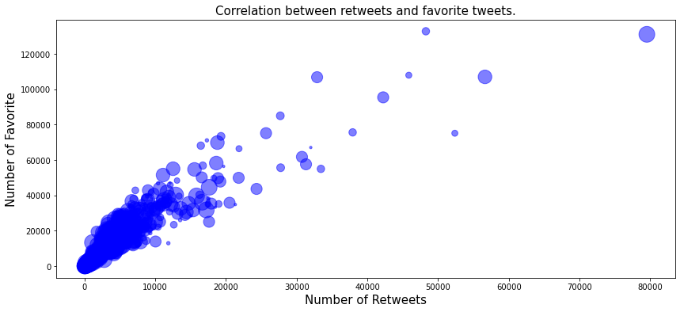

```python
plt.figure(figsize= [14,6])
plt.scatter(x = viz_df['retweet_count'],
            y = viz_df['favorite_count'],alpha=0.5,color= 'blue', sizes = np.array([20,50,100,200,200,300,60,90,10,300,200,400,75]))
plt.xlabel('Number of Retweets', fontsize = 15)
plt.ylabel('Number of Favorite', fontsize = 15)
plt.title('Correlation between retweets and favorite tweets.',
          fontsize = 15)
plt.show()
```

*the correlation between retweets and likes is somewhat positive*

*Q2: Which is the most popular stage among dogs*

```python
viz_df.stage_name.value_counts()
```

```
                  1650
pupper             201
doggo               63
puppo               22
doggo, pupper        8
floofer              7
doggo, puppo         1
doggo, floofer       1
Name: stage_name, dtype: int64
```

*We can see that Pupper is very popular amongst dog stages*

*Q3: Does a high numerator rating correlates to high retweets and favorite count?*

```python
viz_df.plot([x ="retweet_count", "favorite_count"], y="numerator_rating", kind="line",bins=7)
```

[output not shown]

```python
viz_df.retweet_count
```

```
0       8853
1       6514
2       4328
3       8964
4       9774
        ...
1948      41
1949     147
1950      47
1951      48
1952     532
Name: retweet_count, Length: 1953, dtype: int64
```

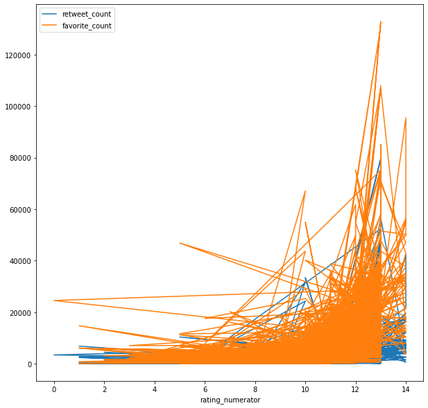

```python
viz_df.plot(x="rating_numerator", y=["retweet_count","favorite_count"], kind="line", figsize=(10,10));
```

*Though the viz isnt that great but we can see that likes and retweets increases as rating numerator increases*

### Insights:

1. There's a probability that the rating numrator is actually a factor of wether the photo gets more likes and retweets
2. Pupper is the most popular stage dogs on the dataset
3. The is a strong correlation between favorite_count and retweet_count

### Visualization

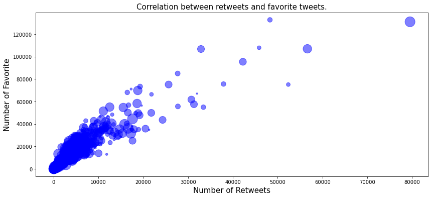

```python
plt.figure(figsize= [14,6])
plt.scatter(x = viz_df['retweet_count'],
            y = viz_df['favorite_count'],alpha=0.5,color= 'blue', sizes = np.array([20,50,100,200,200,300,60,90,10,300,200,400,75]))
plt.xlabel('Number of Retweets', fontsize = 15)
plt.ylabel('Number of Favorite', fontsize = 15)
plt.title('Correlation between retweets and favorite tweets.',
          fontsize = 15)
plt.show()
```

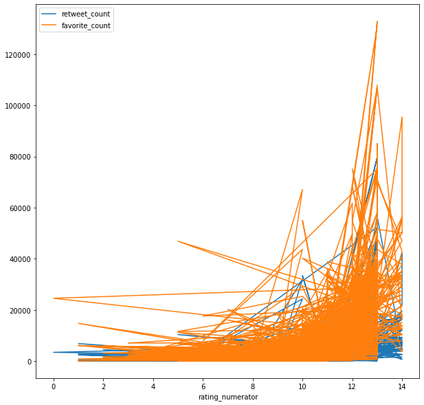

```python
viz_df.plot(x="rating_numerator", y=["retweet_count","favorite_count"], kind="line", figsize=(10,10));
```